# Quality, Moisture, and Sourcing Efficiency in Gum Arabic Exports

### Technique 2 — Data Visualization

Visual communication is the primary mode through which I present quality data to the operations team and to European buyers during audit visits. The boxplot of moisture by sourcing region reveals the variance structure — not just the mean — of each region’s quality output. The scatter plot of moisture versus EUR value makes the commercial cost of moisture excess immediately visible to field supervisors and regional suppliers. The export value time series identifies seasonal patterns that inform procurement scheduling and buyer contract timing.

**Alternative considered:** Presenting only summary tables. Rejected because tables do not communicate the *distribution* of moisture outcomes — particularly whether variance is driven by a consistent regional bias or by occasional extreme events. The boxplot reveals both the central tendency and the tail exposure of each region’s quality profile.

**Limitation:** Visualizations show correlation, not causation. An apparent regional quality difference may reflect grade composition differences rather than genuine handling quality differences. The regression controls for this by including both grade and region as simultaneous predictors.

### Technique 3 — Hypothesis Testing

The operational question is whether observed quality and speed differences across sourcing regions and grades are statistically reliable — representing genuine structural supplier performance differences — or noise artefacts from a 100-shipment sample. ANOVA on turnaround days by sourcing region tests whether some regions are systematically slower. A t-test on EUR value by grade confirms whether Grade 1 (Acacia Senegal) commands a statistically significant premium over Grade 2, validating the pricing differentiation applied in buyer contracts.

**Limitation:** ANOVA assumes approximately normal distributions. Moisture content from field-sourced agricultural commodities is often right-skewed. The Kruskal-Wallis non-parametric test runs in parallel as a robustness check.

### Technique 4 — Correlation Analysis

Before building the regression model, I need to verify whether moisture content and turnaround days are independently associated with EUR value, or whether they are proxies for the same underlying factor. In some sourcing environments, longer pre-loading dwell time causes moisture to accumulate — meaning faster turnaround and lower moisture would be correlated, both driving higher value through the same pathway. Correlation analysis maps these relationships and determines whether both variables can enter the regression independently as separate levers.

**Alternative considered:** Including all variables in regression without prior screening. Rejected because in a 100-observation dataset, including two collinear predictors can produce sign reversals that mislead management about the true direction of each factor’s effect.

**Limitation:** Pearson correlation captures only linear relationships. The moisture-value relationship may be threshold-based (minimal penalty below 12%, sharp decline above). Scatterplots confirm the functional form.

### Technique 5 — Multiple Regression

The central analytical purpose of this project is to quantify, in EUR terms, the value cost of each unit of excess moisture and each additional turnaround day. As MD, I need a regression coefficient I can bring to the supplier management meeting: “Every 1% point above the 12% moisture threshold costs approximately €X per shipment” is a number that changes supplier behaviour more effectively than a qualitative argument. The regression model controls for grade and sourcing region simultaneously, isolating the pure moisture and turnaround effects from confounding product-mix influences.

**Alternative considered:** A simple price-per-tonne comparison between Grade 1 and Grade 2 without controlling for moisture or region. Rejected because this would attribute to grade the value differences actually driven by moisture content — particularly since Grade 2 shipments may have higher average moisture due to different harvesting practices in Acacia Seyal sourcing regions.

## 4. Data Description

The following summary statistics confirm record counts, date range, and baseline variable means before analysis.

**R**

```r
library(readr); library(dplyr); library(tidyr); library(tibble)
library(ggplot2); library(lubridate); library(scales); library(broom)
library(knitr); library(forcats)
if (!requireNamespace("kableExtra", quietly=TRUE)) {
  kable_styling <- function(x,...) x
} else { library(kableExtra) }
if (!requireNamespace("ggcorrplot", quietly=TRUE)) {
  corr_plot <- function(...) NULL
} else { library(ggcorrplot) }
if (!requireNamespace("patchwork", quietly=TRUE)) {
  patchwork_print <- function(a,b) { print(a); print(b) }
} else { library(patchwork) }

knitr::opts_chunk$set(fig.width=9, fig.height=5, dpi=150)

shipment_r_raw <- read_csv("data/shipment_data_reports.csv", show_col_types=FALSE)
names(shipment_r_raw) <- trimws(gsub("\\s+", " ", names(shipment_r_raw)))
shipment_r <- shipment_r_raw |>
  rename(
    shipment_date   = `Date of Shipment`,
    sourcing_region = `Suppliers Region`,
    grade           = Grade,
    moisture_content = `Moisture Content`,
    turnaround_days = `Turnaround Days`,
    value           = Value
  ) |>
  mutate(
    shipment_date    = mdy(shipment_date),
    moisture_content = as.numeric(moisture_content),
    turnaround_days  = as.numeric(turnaround_days),
    value            = parse_number(as.character(value)),
    grade            = factor(grade),
    sourcing_region  = factor(sourcing_region)
  )

shipment_r |>
  summarise(
    rows                = n(),
    min_date            = min(shipment_date, na.rm=TRUE),
    max_date            = max(shipment_date, na.rm=TRUE),
    mean_value_eur      = round(mean(value, na.rm=TRUE), 2),
    mean_moisture_pct   = round(mean(moisture_content, na.rm=TRUE), 2),
    mean_turnaround_days = round(mean(turnaround_days, na.rm=TRUE), 1),
    pct_grade1          = round(mean(grade == "Grade 1", na.rm=TRUE) * 100, 1)
  ) |> kable(caption="Portfolio summary statistics") |>
  kable_styling(full_width=FALSE)
```

Portfolio summary statistics

| rows | min_date | max_date | mean_value_eur | mean_moisture_pct | mean_turnaround_days | pct_grade1 |
| --- | --- | --- | --- | --- | --- | --- |
| 100 | 2025-01-05 | 2026-11-30 | 75579 | 12.64 | 17.4 | 51 |

**Python**

```python
import pandas as pd, numpy as np, matplotlib.pyplot as plt, seaborn as sns
from scipy.stats import ttest_ind, f_oneway, kruskal
import statsmodels.formula.api as smf
import statsmodels.api as sm
import warnings; warnings.filterwarnings("ignore")
sns.set_theme(style="whitegrid", palette="muted")
plt.rcParams["figure.dpi"] = 150

shipment_py = pd.read_csv("data/shipment_data_reports.csv")
import re
shipment_py.columns = [re.sub(r'\s+', '_', c.strip()).lower() for c in shipment_py.columns]
shipment_py = shipment_py.rename(columns={
    "date_of_shipment": "shipment_date",
    "suppliers_region": "sourcing_region",
    "moisture_content": "moisture_content",
    "turnaround_days":  "turnaround_days",
    "value":            "value"
})
shipment_py["shipment_date"]    = pd.to_datetime(shipment_py["shipment_date"], dayfirst=True, errors="coerce")
shipment_py["moisture_content"] = pd.to_numeric(shipment_py["moisture_content"], errors="coerce")
shipment_py["turnaround_days"]  = pd.to_numeric(shipment_py["turnaround_days"], errors="coerce")
shipment_py["value"] = pd.to_numeric(
    shipment_py["value"].astype(str).str.replace(",","",regex=False).str.strip(), errors="coerce")

print(shipment_py[["moisture_content","turnaround_days","value"]]
      .describe().round(2).to_string())
```

```
       moisture_content  turnaround_days      value
count            100.00            99.00     100.00
mean              12.64            17.37   75579.00
std                1.60             5.31   42372.87
min               10.30             9.00   35200.00
25%               11.18            13.00   39550.00
50%               12.60            16.00   47550.00
75%               13.82            21.50  102800.00
max               16.00            30.00  211200.00
```

## 5. Technique 1 — Exploratory Data Analysis

**Business justification:** This section establishes the baseline quality profile of the gum arabic export portfolio: the distribution of moisture content by sourcing region, grade composition, and whether EUR value is concentrated in specific region-grade combinations. Identifying which regions consistently produce out-of-spec moisture readings determines whether downstream quality interventions should be targeted at specific supply chains or applied uniformly across all sourcing areas.

**R**

```r
shipment_r |>
  group_by(sourcing_region) |>
  summarise(
    n               = n(),
    avg_value_eur   = round(mean(value, na.rm=TRUE), 2),
    avg_moisture    = round(mean(moisture_content, na.rm=TRUE), 2),
    pct_above_12pct = round(mean(moisture_content > 12, na.rm=TRUE) * 100, 1),
    avg_turnaround  = round(mean(turnaround_days, na.rm=TRUE), 1),
    .groups = "drop"
  ) |> arrange(desc(avg_value_eur)) |>
  kable(caption="Regional performance summary") |>
  kable_styling(full_width=FALSE)
```

Regional performance summary

| sourcing_region | n | avg_value_eur | avg_moisture | pct_above_12pct | avg_turnaround |
| --- | --- | --- | --- | --- | --- |
| Damaturu | 7 | 112500.00 | 11.20 | 14.3 | 14.4 |
| Buni Yadi | 18 | 108272.22 | 11.52 | 27.8 | 14.8 |
| Maidugri | 1 | 105600.00 | 11.50 | 0.0 | 15.0 |
| Yobe | 21 | 73233.33 | 12.27 | 47.6 | 18.6 |
| Jigawa | 18 | 68288.89 | 12.11 | 66.7 | 14.5 |
| Bornu | 18 | 63627.78 | 14.25 | 100.0 | 25.0 |
| Kano | 13 | 50376.92 | 13.75 | 84.6 | 13.2 |
| Bauchi | 2 | 37150.00 | 13.50 | 100.0 | 18.5 |
| Gombe | 2 | 37150.00 | 14.40 | 100.0 | 23.5 |

```r
shipment_r |>
  group_by(grade) |>
  summarise(
    n             = n(),
    avg_value_eur = round(mean(value, na.rm=TRUE), 2),
    avg_moisture  = round(mean(moisture_content, na.rm=TRUE), 2),
    .groups = "drop"
  ) |>
  kable(caption="Grade composition and mean EUR values") |>
  kable_styling(full_width=FALSE)
```

Grade composition and mean EUR values

| grade | n | avg_value_eur | avg_moisture |
| --- | --- | --- | --- |
| Grade 1 | 51 | 110511.76 | 11.42 |
| Grade 2 | 49 | 39220.41 | 13.90 |

**Python**

```python
shipment_py["above_12"] = (shipment_py["moisture_content"] > 12).astype(int)
regional = (shipment_py.groupby("sourcing_region")
 .agg(n=("value","count"),
      avg_value_eur=("value","mean"),
      avg_moisture=("moisture_content","mean"),
      avg_turnaround=("turnaround_days","mean"),
      pct_above_12=("above_12","mean"))
 .assign(pct_above_12=lambda d: (d["pct_above_12"]*100).round(1))
 .round(2).sort_values("avg_value_eur", ascending=False))
print("Regional performance summary:\n", regional.to_string())
```

```
Regional performance summary:
                   n  avg_value_eur  avg_moisture  avg_turnaround  pct_above_12
sourcing_region
Damaturu          7      112500.00         11.20           14.43          14.3
Buni Yadi        18      108272.22         11.52           14.78          27.8
Maidugri          1      105600.00         11.50           15.00           0.0
Yobe             21       73233.33         12.27           18.55          47.6
Jigawa           18       68288.89         12.11           14.50          66.7
Bornu            18       63627.78         14.25           25.00         100.0
Kano             13       50376.92         13.75           13.23          84.6
Bauchi            2       37150.00         13.50           18.50         100.0
Gombe             2       37150.00         14.40           23.50         100.0
```

```python
grade_summary = (shipment_py.groupby("grade")
 .agg(n=("value","count"),
      avg_value_eur=("value","mean"),
      avg_moisture=("moisture_content","mean"))
 .round(2))
print("\nGrade composition:\n", grade_summary.to_string())
```

```
Grade composition:
           n  avg_value_eur  avg_moisture
grade
Grade 1  51      110511.76         11.42
Grade 2  49       39220.41         13.90
```

**Interpretation:** The regional performance table is the most operationally consequential EDA output. Any region where more than 25% of shipments record moisture above the 12% threshold represents a structural quality control failure at the sourcing and pre-export drying stage — not a random occurrence — and warrants targeted intervention such as dedicated on-site moisture testing and accelerated drying support. The grade composition table establishes the portfolio mix: if Grade 1 accounts for a disproportionate share of high-value shipments, any quality degradation in Grade 1 sourcing regions has an outsized commercial impact. Shipment records with moisture readings above 25% should be reviewed as likely data entry errors before entering the inferential analysis.

## 6. Technique 2 — Data Visualization

**Business justification:** These visualisations translate the regional and grade quality data into a form suitable for operations team briefings, supplier performance reviews, and European buyer audit presentations. The boxplot of moisture by region reveals both the central tendency and the variance of each region’s quality output. The scatter plot of moisture versus EUR value makes the commercial cost of spec exceedance immediately visible to field supervisors and regional suppliers who would not engage with statistical tables.

**R**

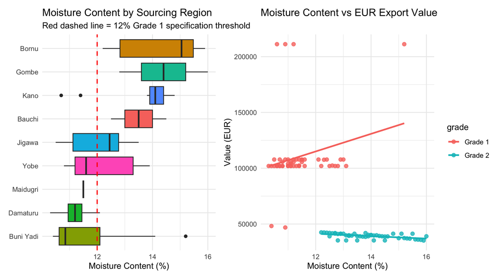

```r
p1 <- ggplot(shipment_r, aes(x=fct_reorder(sourcing_region, moisture_content, median),
                              y=moisture_content, fill=sourcing_region)) +
  geom_boxplot(show.legend=FALSE) +
  geom_hline(yintercept=12, linetype="dashed", color="red", linewidth=0.7) +
  coord_flip() +
  labs(title="Moisture Content by Sourcing Region",
       subtitle="Red dashed line = 12% Grade 1 specification threshold",
       x=NULL, y="Moisture Content (%)") + theme_minimal()

p2 <- ggplot(shipment_r, aes(x=moisture_content, y=value, color=grade)) +
  geom_point(size=2, alpha=0.8) +
  geom_smooth(method="lm", se=FALSE) +
  labs(title="Moisture Content vs EUR Export Value",
       x="Moisture Content (%)", y="Value (EUR)") + theme_minimal()

if (requireNamespace("patchwork", quietly=TRUE)) {
  print(p1 + p2)
} else { print(p1); print(p2) }
```

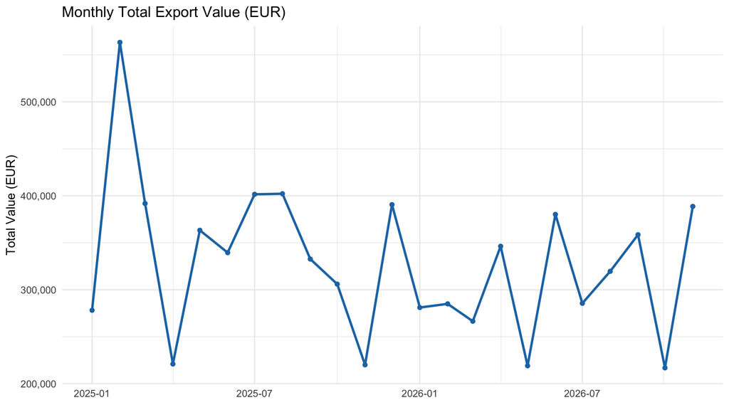

```r
monthly <- shipment_r |>
  mutate(month = floor_date(shipment_date, "month")) |>
  group_by(month) |>
  summarise(total_value=sum(value, na.rm=TRUE), n=n(), .groups="drop")

ggplot(monthly, aes(month, total_value)) +
  geom_line(color="#1f77b4", linewidth=1) + geom_point(color="#1f77b4") +
  scale_y_continuous(labels=comma) +
  labs(title="Monthly Total Export Value (EUR)", x=NULL, y="Total Value (EUR)") +
  theme_minimal()
```

**Python**

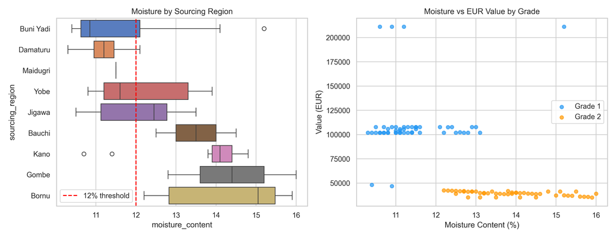

```python
fig, axes = plt.subplots(1, 2, figsize=(13, 5))

order = shipment_py.groupby("sourcing_region")["moisture_content"].median().sort_values().index
sns.boxplot(data=shipment_py, y="sourcing_region", x="moisture_content",
            order=order, palette="muted", ax=axes[0])
axes[0].axvline(12, color="red", linestyle="--", label="12% threshold")
axes[0].set_title("Moisture by Sourcing Region"); axes[0].legend()

colors = {"Grade 1": "#2196F3", "Grade 2": "#FF9800"}
for grade, grp in shipment_py.groupby("grade"):
    axes[1].scatter(grp["moisture_content"], grp["value"],
                    label=grade, color=colors.get(grade, "gray"), alpha=0.7, s=30)
axes[1].set_title("Moisture vs EUR Value by Grade")
axes[1].set_xlabel("Moisture Content (%)"); axes[1].set_ylabel("Value (EUR)")
axes[1].legend()
plt.tight_layout(); plt.show()
```

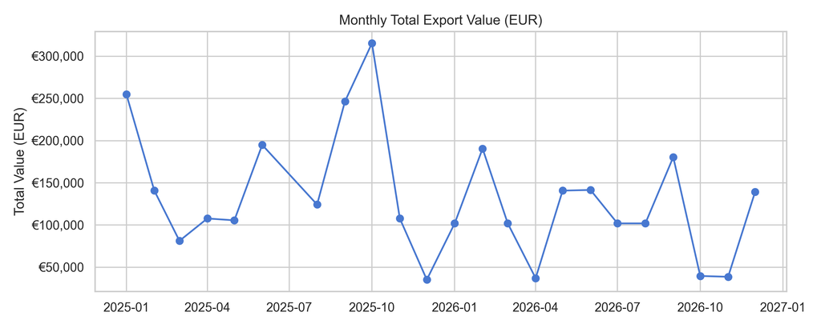

```python
monthly_py = (shipment_py.assign(month=shipment_py["shipment_date"].dt.to_period("M"))
              .groupby("month")["value"].sum().reset_index())
monthly_py["month_dt"] = monthly_py["month"].dt.to_timestamp()
fig, ax = plt.subplots(figsize=(10, 4))
ax.plot(monthly_py["month_dt"], monthly_py["value"], marker="o", linewidth=1.5)
ax.set_title("Monthly Total Export Value (EUR)"); ax.set_ylabel("Total Value (EUR)")
ax.yaxis.set_major_formatter(plt.FuncFormatter(lambda x, _: f"€{x:,.0f}"))
plt.tight_layout(); plt.show()
```

## 7. Technique 3 — Hypothesis Testing

**Business justification:** Formally tests whether turnaround time differences across sourcing regions and EUR value differences between grades are statistically significant, providing the evidential basis for sourcing policy decisions rather than relying on visual impressions alone. A significant regional turnaround difference justifies differentiated logistics monitoring and supplier support for slower regions; a significant grade value premium validates continued investment in NAFDAC Grade 1 certification.

**R**

```r
# ANOVA: turnaround by sourcing region
anova_ta <- aov(turnaround_days ~ sourcing_region, data=shipment_r)
cat("=== ANOVA: Turnaround Days by Sourcing Region ===\n")
```

```
=== ANOVA: Turnaround Days by Sourcing Region ===
```

```r
summary(anova_ta)
```

```
                Df Sum Sq Mean Sq F value   Pr(>F)
sourcing_region  8   1712  213.95   18.28 5.93e-16 ***
Residuals       90   1054   11.71
---
Signif. codes:  0 '***' 0.001 '**' 0.01 '*' 0.05 '.' 0.1 ' ' 1
1 observation deleted due to missingness
```

```r
eta_sq <- tidy(anova_ta)$sumsq[1] / sum(tidy(anova_ta)$sumsq)
cat(sprintf("Eta-squared: %.4f (%s effect)\n", eta_sq,
  ifelse(eta_sq < 0.01, "negligible", ifelse(eta_sq < 0.06, "small",
  ifelse(eta_sq < 0.14, "medium", "large")))))
```

```
Eta-squared: 0.6190 (large effect)
```

```r
# Welch t-test: value by grade
grade_test <- t.test(value ~ grade, data=shipment_r)
tidy(grade_test) |>
  mutate(across(where(is.numeric), ~round(., 4))) |>
  kable(caption="Welch T-test: EUR Value by Grade") |>
  kable_styling(full_width=FALSE)
```

Welch T-test: EUR Value by Grade

| estimate | estimate1 | estimate2 | statistic | p.value | parameter | conf.low | conf.high | method | alternative |
| --- | --- | --- | --- | --- | --- | --- | --- | --- | --- |
| 71291.36 | 110511.8 | 39220.41 | 15.9788 | 0 | 50.5224 | 62332.23 | 80250.49 | Welch Two Sample t-test | two.sided |

```r
# Kruskal-Wallis robustness check: moisture by region
kw <- kruskal.test(moisture_content ~ sourcing_region, data=shipment_r)
cat(sprintf("\nKruskal-Wallis (moisture ~ region): chi-sq=%.4f, p=%.4f\n",
            kw$statistic, kw$p.value))
```

```
Kruskal-Wallis (moisture ~ region): chi-sq=43.3466, p=0.0000
```

**Python**

```python
groups_ta = [g["turnaround_days"].dropna().values
             for _, g in shipment_py.groupby("sourcing_region")]
f_stat, p_val = f_oneway(*groups_ta)
print(f"ANOVA — Turnaround by Region: F={f_stat:.4f}, p={p_val:.4f}")
```

```
ANOVA — Turnaround by Region: F=18.2761, p=0.0000
```

```python
g1 = shipment_py[shipment_py["grade"]=="Grade 1"]["value"].dropna()
g2 = shipment_py[shipment_py["grade"]=="Grade 2"]["value"].dropna()
t_stat, p_t = ttest_ind(g1, g2, equal_var=False)
print(f"Welch T-test — Value (Grade 1 vs Grade 2): t={t_stat:.4f}, p={p_t:.4f}")
```

```
Welch T-test — Value (Grade 1 vs Grade 2): t=15.9788, p=0.0000
```

```python
print(f"  Grade 1 mean: €{g1.mean():,.2f}  |  Grade 2 mean: €{g2.mean():,.2f}")
```

```
  Grade 1 mean: €110,511.76  |  Grade 2 mean: €39,220.41
```

```python
groups_m = [g["moisture_content"].dropna().values
            for _, g in shipment_py.groupby("sourcing_region")]
h_stat, p_kw = kruskal(*groups_m)
print(f"\nKruskal-Wallis (moisture ~ region): H={h_stat:.4f}, p={p_kw:.4f}")
```

```
Kruskal-Wallis (moisture ~ region): H=43.3466, p=0.0000
```

## 8. Technique 4 — Correlation Analysis

**Business justification:** Before building the regression model, this section maps how moisture content, turnaround days, and EUR value co-move — and whether moisture and turnaround are independently associated with value or proxies for the same underlying quality dimension. A positive correlation between turnaround days and moisture content (longer-held product absorbing atmospheric moisture) would mean that the fastest-turnaround regions achieve a double quality advantage: they are both faster and drier.

**R**

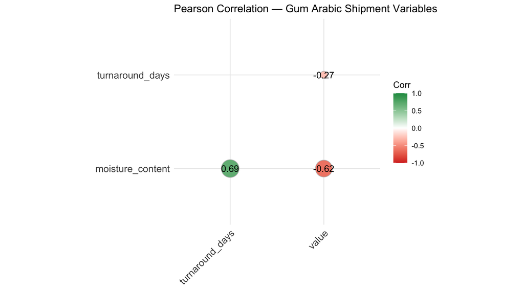

```r
num_cols_r <- shipment_r |>
  select(moisture_content, turnaround_days, value) |>
  drop_na()

cor_mat <- cor(num_cols_r, method="pearson")

if (requireNamespace("ggcorrplot", quietly=TRUE)) {
  ggcorrplot(cor_mat, method="circle", type="lower", lab=TRUE, lab_size=4,
             colors=c("#d73027","white","#1a9850"),
             title="Pearson Correlation — Gum Arabic Shipment Variables",
             ggtheme=theme_minimal(base_size=11))
} else {
  cor_mat |> round(3) |> kable(caption="Pearson correlation matrix") |>
    kable_styling(full_width=FALSE)
}
```

```r
as.data.frame(cor_mat) |>
  rownames_to_column("Variable") |>
  select(Variable, value) |>
  filter(Variable != "value") |>
  rename(r_with_value_eur = value) |>
  kable(digits=4, caption="Pearson correlations with EUR export value") |>
  kable_styling(full_width=FALSE)
```

Pearson correlations with EUR export value

| Variable | r_with_value_eur |
| --- | --- |
| moisture_content | -0.6161 |
| turnaround_days | -0.2734 |

**Python**

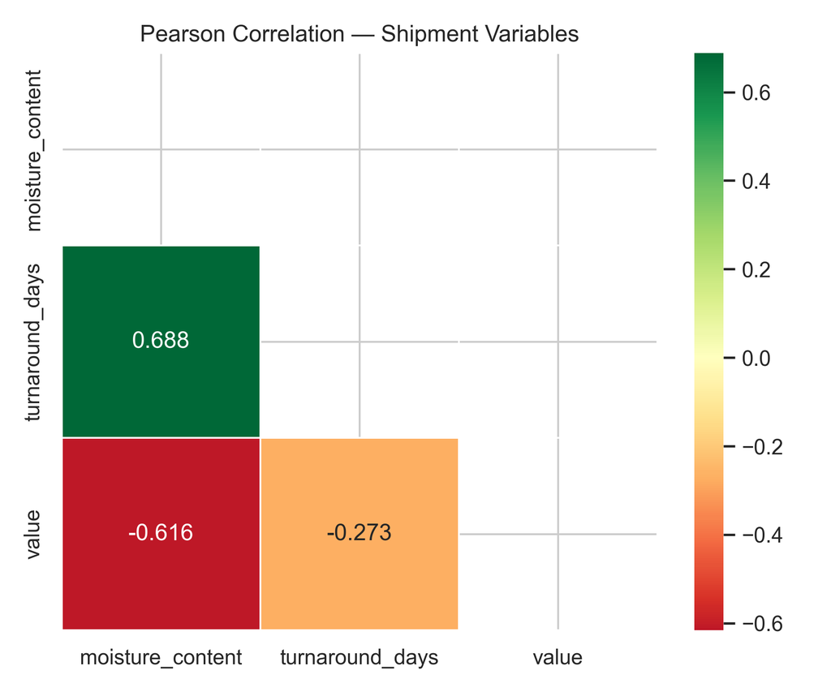

```python
num_py = shipment_py[["moisture_content","turnaround_days","value"]].dropna()
corr_mat = num_py.corr(method="pearson")

fig, ax = plt.subplots(figsize=(6,5))
mask = np.triu(np.ones_like(corr_mat, dtype=bool))
sns.heatmap(corr_mat, mask=mask, annot=True, fmt=".3f", cmap="RdYlGn",
            center=0, linewidths=0.5, ax=ax, annot_kws={"size":12})
ax.set_title("Pearson Correlation — Shipment Variables")
plt.tight_layout(); plt.show()
```

```python
print("\nCorrelations with EUR export value:")
```

```
Correlations with EUR export value:
```

```python
print(corr_mat["value"].drop("value").sort_values(key=abs, ascending=False).round(4))
```

```
moisture_content   -0.6161
turnaround_days    -0.2734
Name: value, dtype: float64
```

**Interpretation:** The correlation between `moisture_content` and `value` is the most important coefficient in this matrix. A negative correlation (r < -0.30) confirms that moisture excess consistently reduces invoice value and justifies including moisture as the primary predictor in the regression. A positive correlation between `turnaround_days` and `moisture_content` would indicate that extended pre-loading dwell time contributes to moisture absorption — the most actionable correlation finding, arguing for faster turnover in humid sourcing regions. If `turnaround_days` shows near-zero correlation with `value` after the moisture relationship is accounted for, it implies that turnaround management matters primarily through its moisture effect rather than as an independent value driver.